# Basics of Inferential Modeling

Inferential modeling is a statistical approach used to draw conclusions about a population based on a sample of data. The Statsmodels library in Python provides tools for building and analyzing inferential models, including regression models, time series models, and other advanced statistical techniques.

As an exercise, I will be using the famous Boston dataset.

The [Boston dataset](https://cran.r-project.org/web/packages/MASS/MASS.pdf) is a built-in dataset in Statsmodels that contains information about housing in the Boston area. The dataset contains 506 observations and 14 columns:

- `crim`: per capita crime rate by town
- `zn`: proportion of residential land zoned for lots over 25,000 sq.ft.
- `indus`: proportion of non-retail business acres per town
- `chas`: Charles River dummy variable (= 1 if tract bounds river; 0 otherwise)
- `nox`: nitric oxides concentration (parts per 10 million)
- `rm`: average number of rooms per dwelling
- `age`: proportion of owner-occupied units built prior to 1940
- `dis`: weighted mean of distances to five Boston employment centres
- `rad`: index of accessibility to radial highways
- `tax`: full-value property-tax rate per $10,000
- `ptratio`: pupil-teacher ratio by town
- `black`: 1000(Bk - 0.63)^2 where Bk is the proportion of blacks by town
- `lstat`: lower status of the population (%)
- `medv`: median value of owner-occupied homes in $1000s

The goal in this exercise is to fit a linear regression model to infer properties about the relationships between the response variable `medv` and input variables.

```python
# Import relevant libraries
import numpy as np
import pandas as pd
import statsmodels.api as sm
import matplotlib.pyplot as plt
import seaborn as sns
sns.set()
```

```python
# Load dataset
from statsmodels.datasets import get_rdataset
data = get_rdataset('Boston', 'MASS').data
```

```python
data.head()
```

|  | crim | zn | indus | chas | nox | rm | age | dis | rad | tax | ptratio | black | lstat | medv |
| --- | --- | --- | --- | --- | --- | --- | --- | --- | --- | --- | --- | --- | --- | --- |
| 0 | 0.00632 | 18.0 | 2.31 | 0 | 0.538 | 6.575 | 65.2 | 4.0900 | 1 | 296 | 15.3 | 396.90 | 4.98 | 24.0 |
| 1 | 0.02731 | 0.0 | 7.07 | 0 | 0.469 | 6.421 | 78.9 | 4.9671 | 2 | 242 | 17.8 | 396.90 | 9.14 | 21.6 |
| 2 | 0.02729 | 0.0 | 7.07 | 0 | 0.469 | 7.185 | 61.1 | 4.9671 | 2 | 242 | 17.8 | 392.83 | 4.03 | 34.7 |
| 3 | 0.03237 | 0.0 | 2.18 | 0 | 0.458 | 6.998 | 45.8 | 6.0622 | 3 | 222 | 18.7 | 394.63 | 2.94 | 33.4 |
| 4 | 0.06905 | 0.0 | 2.18 | 0 | 0.458 | 7.147 | 54.2 | 6.0622 | 3 | 222 | 18.7 | 396.90 | 5.33 | 36.2 |

```python
data.info()
```

```
<class 'pandas.core.frame.DataFrame'>
RangeIndex: 506 entries, 0 to 505
Data columns (total 14 columns):
 #   Column   Non-Null Count  Dtype
---  ------   --------------  -----
 0   crim     506 non-null    float64
 1   zn       506 non-null    float64
 2   indus    506 non-null    float64
 3   chas     506 non-null    int64
 4   nox      506 non-null    float64
 5   rm       506 non-null    float64
 6   age      506 non-null    float64
 7   dis      506 non-null    float64
 8   rad      506 non-null    int64
 9   tax      506 non-null    int64
 10  ptratio  506 non-null    float64
 11  black    506 non-null    float64
 12  lstat    506 non-null    float64
 13  medv     506 non-null    float64
dtypes: float64(11), int64(3)
memory usage: 55.5 KB
```

```python
data.duplicated().sum()
```

```
0
```

```python
data.describe(include='all')
```

|  | crim | zn | indus | chas | nox | rm | age | dis | rad | tax | ptratio | black | lstat | medv |
| --- | --- | --- | --- | --- | --- | --- | --- | --- | --- | --- | --- | --- | --- | --- |
| count | 506.000000 | 506.000000 | 506.000000 | 506.000000 | 506.000000 | 506.000000 | 506.000000 | 506.000000 | 506.000000 | 506.000000 | 506.000000 | 506.000000 | 506.000000 | 506.000000 |
| mean | 3.613524 | 11.363636 | 11.136779 | 0.069170 | 0.554695 | 6.284634 | 68.574901 | 3.795043 | 9.549407 | 408.237154 | 18.455534 | 356.674032 | 12.653063 | 22.532806 |
| std | 8.601545 | 23.322453 | 6.860353 | 0.253994 | 0.115878 | 0.702617 | 28.148861 | 2.105710 | 8.707259 | 168.537116 | 2.164946 | 91.294864 | 7.141062 | 9.197104 |
| min | 0.006320 | 0.000000 | 0.460000 | 0.000000 | 0.385000 | 3.561000 | 2.900000 | 1.129600 | 1.000000 | 187.000000 | 12.600000 | 0.320000 | 1.730000 | 5.000000 |
| 25% | 0.082045 | 0.000000 | 5.190000 | 0.000000 | 0.449000 | 5.885500 | 45.025000 | 2.100175 | 4.000000 | 279.000000 | 17.400000 | 375.377500 | 6.950000 | 17.025000 |
| 50% | 0.256510 | 0.000000 | 9.690000 | 0.000000 | 0.538000 | 6.208500 | 77.500000 | 3.207450 | 5.000000 | 330.000000 | 19.050000 | 391.440000 | 11.360000 | 21.200000 |
| 75% | 3.677083 | 12.500000 | 18.100000 | 0.000000 | 0.624000 | 6.623500 | 94.075000 | 5.188425 | 24.000000 | 666.000000 | 20.200000 | 396.225000 | 16.955000 | 25.000000 |
| max | 88.976200 | 100.000000 | 27.740000 | 1.000000 | 0.871000 | 8.780000 | 100.000000 | 12.126500 | 24.000000 | 711.000000 | 22.000000 | 396.900000 | 37.970000 | 50.000000 |

At a glance, the Boston dataset appears to be clean. There are no null or duplicate observations, and its descriptive statistics seem reasonable. As such, no data cleaning will be necessary.

Without regard for OLS assumptions, lets us first take a look at how the regression summary would look like if we simply regressed `medv` on the available input variables (without transforming them).

```python
model = sm.OLS(data['medv'], sm.add_constant(data[['crim', 'zn', 'indus', 'chas', 'nox', 'rm', 'age', 'dis', 'rad', 'tax', 'ptratio', 'black', 'lstat']])).fit()
```

```python
print(model.summary())
```

```
                            OLS Regression Results
==============================================================================
Dep. Variable:                   medv   R-squared:                       0.741
Model:                            OLS   Adj. R-squared:                  0.734
Method:                 Least Squares   F-statistic:                     108.1
Date:                Fri, 31 Mar 2023   Prob (F-statistic):          6.72e-135
Time:                        20:16:36   Log-Likelihood:                -1498.8
No. Observations:                 506   AIC:                             3026.
Df Residuals:                     492   BIC:                             3085.
Df Model:                          13
Covariance Type:            nonrobust
==============================================================================
                 coef    std err          t      P>|t|      [0.025      0.975]
------------------------------------------------------------------------------
const         36.4595      5.103      7.144      0.000      26.432      46.487
crim          -0.1080      0.033     -3.287      0.001      -0.173      -0.043
zn             0.0464      0.014      3.382      0.001       0.019       0.073
indus          0.0206      0.061      0.334      0.738      -0.100       0.141
chas           2.6867      0.862      3.118      0.002       0.994       4.380
nox          -17.7666      3.820     -4.651      0.000     -25.272     -10.262
rm             3.8099      0.418      9.116      0.000       2.989       4.631
age            0.0007      0.013      0.052      0.958      -0.025       0.027
dis           -1.4756      0.199     -7.398      0.000      -1.867      -1.084
rad            0.3060      0.066      4.613      0.000       0.176       0.436
tax           -0.0123      0.004     -3.280      0.001      -0.020      -0.005
ptratio       -0.9527      0.131     -7.283      0.000      -1.210      -0.696
black          0.0093      0.003      3.467      0.001       0.004       0.015
lstat         -0.5248      0.051    -10.347      0.000      -0.624      -0.425
==============================================================================
Omnibus:                      178.041   Durbin-Watson:                   1.078
Prob(Omnibus):                  0.000   Jarque-Bera (JB):              783.126
Skew:                           1.521   Prob(JB):                    8.84e-171
Kurtosis:                       8.281   Cond. No.                     1.51e+04
==============================================================================

Notes:
[1] Standard Errors assume that the covariance matrix of the errors is correctly specified.
[2] The condition number is large, 1.51e+04. This might indicate that there are
strong multicollinearity or other numerical problems.
```

Immediately, we observe that `indus` and `age` have very large p-values that are greater than 0.05 which the conventionally required level of significance. As such, they are statistically insignificant and it may be permissible to exclude them from our model.

By definition, p-value represents the smallest level of significance where we can still reject the null hypothesis, given the observed test statistic. That is, under the null hypothesis, p-value tells us the probability of obtaining an effect at least as large as the one observed in our sample. To consider a variable to be statistically significant, the p-value has to be less than the required level of significance.

Secondly, we note that the adjusted R-squared value 0.734, which tell us that 73.4% of the variation in `medv` can be explained by our model.

By definition, R-squared is the coefficient of determination, which is the proportion of the variation in the dependent variable that is predictable from the independent variable(s). It is a measure of goodness of fit of a model, and a statistical measure of how well the regression predictions approximate the real data points.

## OLS Assumptions

In practice before conducting inferential modeling, it's important to check that the assumptions of linear regression are met.

- Linearity in Parameters
- Random Sampling (assumed to be true from data collected)
- Independence (No Perfect Collinearity among Covariates)
- Exogeneity
- Homoscedasticity (constant variance) of Errors
- Normality of Residuals

### Linearity in Parameters

This assumption requires that the relationship between the independent variables and the dependent variable is linear, which means that a change in the independent variable will result in a proportional change in the dependent variable. If the relationship is not linear, then the model may not accurately capture the relationship between the variables and the model's predictions may be biased or unreliable.

If there is evidence of non-linearity in the relationship between the independent variables and the dependent variable, we may need to transform the data or use non-linear regression models, such as polynomial regression or spline regression, to capture the non-linear relationship.

To check for linearity, we can create scatter plots of the dependent variable `medv` against each independent variable. If the points in the scatter plot form a straight line, it suggests that a linear relationship is present.

If we observe an non-linear relationship that is obvious, we improve our model by applying the necessary variable transformation to achieve linearity.

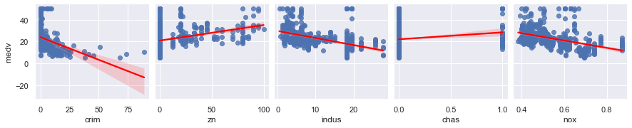

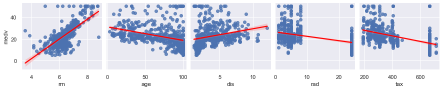

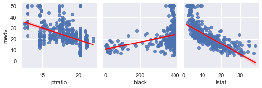

```python
sns.pairplot(data, x_vars=['crim', 'zn', 'indus', 'chas', 'nox'], y_vars='medv', kind='reg', plot_kws={'line_kws':{'color':'red'}})
sns.pairplot(data, x_vars=['rm', 'age', 'dis', 'rad', 'tax'], y_vars='medv', kind='reg', plot_kws={'line_kws':{'color':'red'}})
sns.pairplot(data, x_vars=['ptratio', 'black', 'lstat'], y_vars='medv', kind='reg', plot_kws={'line_kws':{'color':'red'}})
plt.show()
```

### Independence (No Perfect Collinearity among Covariates)

If an independent variable is an exact linear combination of other independent variables, we say that the model suffers from perfect collinearity, and it cannot be estimated by OLS. In reality, a lot of data is naturally correlated. Multicollinearity is a problem in regression analysis since we can't hold correlated coefficients constant. Additionally, it increases the standard error of the coefficients, which results in them potentially showing as statistically insignificant when they might actually be significant.

To check for multicollinearity, we can either visually inspect a correlation heatmap, or examine the Variance Inflation Factor (VIF) of each predictor. Variables with correlation coefficients greater than 0.7 or less than -0.7 are typically considered to be highly correlated, and a VIF value of 1 indicates no multicollinearity, while values greater than 1 indicate increasing levels of multicollinearity. VIF values exceeding 5 are usually indicate high multicollinearity.

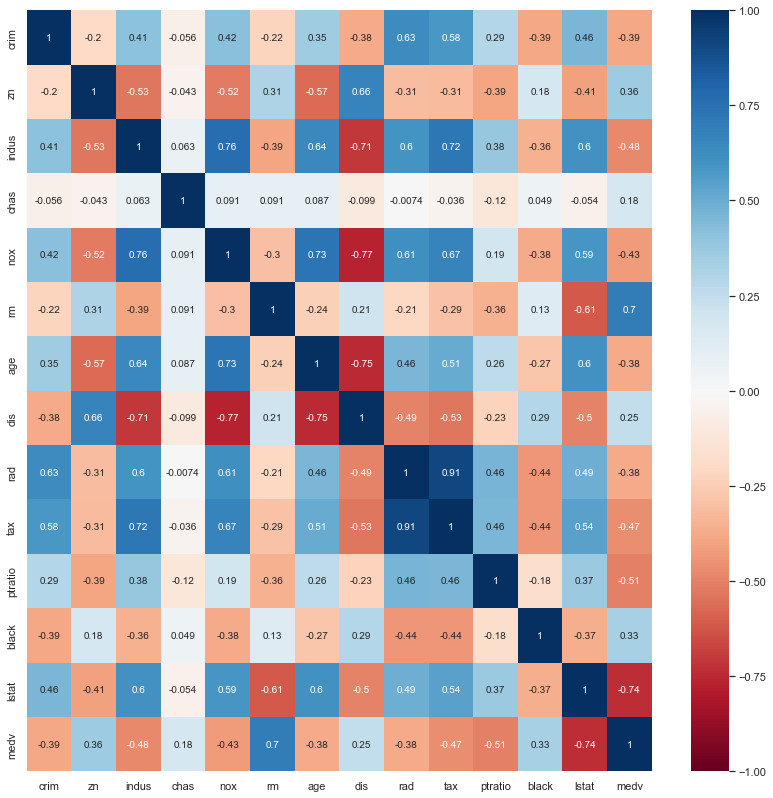

```python
fig, ax = plt.subplots(figsize=(14,14))
corr_matrix = data.corr()
sns.heatmap(data.corr(), vmin=-1, vmax=1, annot=True, cmap="RdBu", ax=ax)
plt.show()
```

It appears that many independent variables are highly correlated with each other, which is problematic. In the case of Boston dataset, it may be wise to build a model from the ground up, hypothesizing on what might most likely be the main factors affecting `medv`.

Otherwise, we can consider iteratively removing variables with the highest VIF value from our model.

```python
from statsmodels.stats.outliers_influence import variance_inflation_factor

# compute the VIF values for the predictors
X = data.drop('medv', axis=1)
X = sm.add_constant(X)  # add a constant term for the intercept
vif = pd.DataFrame()
vif['features'] = X.columns
vif['VIF Factor'] = [variance_inflation_factor(X.values, i) for i in range(X.shape[1])]
print(vif.sort_values(by='VIF Factor', ascending=False))
```

```
   features  VIF Factor
0     const  585.265238
10      tax    9.008554
9       rad    7.484496
5       nox    4.393720
3     indus    3.991596
8       dis    3.955945
7       age    3.100826
13    lstat    2.941491
2        zn    2.298758
6        rm    1.933744
11  ptratio    1.799084
1      crim    1.792192
12    black    1.348521
4      chas    1.073995
```

### Exogeneity

The exogeneity assumption is such that the dependent variable does not causally affect its independent variables. Its formal definition is the zero conditional mean of errors, that is to say that the error term is uncorrelated with the regressors.

The presence of omitted-variable bias (OVB) violates this assumption, and causes the OLS estimators to be biased and inconsistent. To address OVB, we can consider introducing proxy variables or use instrumental variable (IV) techniques such as the two-stage least squares regression. Proxy variables, on the other hand, are variables that are used as a substitute for a variable of interest when the variable of interest is not available or cannot be measured directly. On the other hand, instrumental variables are variables that are correlated with the independent variable of interest, but are not affected by the error term in the regression equation.

To check for exogeneity, we can construct a residual plot. If the residuals are randomly scattered around the zero line, it suggests that the independent variables are exogenous.

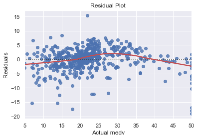

```python
y_pred = model.predict()
sns.residplot(y=y_pred, x=data['medv'], lowess=True, line_kws=dict(color="r"))
plt.xlabel("Actual medv")
plt.ylabel("Residuals")
plt.title("Residual Plot")
plt.show()
```

### Homoscedasticity (constant variance) of Errors

To formally test for homoscedasticity, we can use the Breusch-Pagan test. The test involves regressing the squared residuals on the independent variables and then testing whether the slope coefficient of the independent variable is significantly different from zero. If the p-value of the test is less than the required level of significance (0.05), then we can reject the null hypothesis of homoscedasticity and conclude that there is heteroscedasticity.

In the presence of heteroscedasticity, we can opt to use robust standard errors instead (given that our sample is sufficiently large).

```python
from statsmodels.stats.diagnostic import het_breuschpagan

# Breusch-Pagan test
_, pval, _, _ = het_breuschpagan(model.resid, X)
print('Breusch-Pagan test p-value: ', pval)
```

```
Breusch-Pagan test p-value:  6.265430719876013e-09
```

We reject the null hypothesis and conclude that there is in fact heteroscedasticity present. To address this, we can use the White or Huber-White estimator of the covariance matrix, which provides consistent standard errors that are robust to heteroscedasticity. We can specify this estimator using cov_type='HC3' as the argument in the fit() method of the statsmodels library.

```python
X = data.drop('medv', axis=1)
y = data['medv']

# Fit a linear regression model with heteroscedasticity-robust standard errors
model_robust = sm.OLS(y, sm.add_constant(X)).fit(cov_type='HC3')

print(model_robust.summary())
```

```
                            OLS Regression Results
==============================================================================
Dep. Variable:                   medv   R-squared:                       0.741
Model:                            OLS   Adj. R-squared:                  0.734
Method:                 Least Squares   F-statistic:                     87.08
Date:                Fri, 31 Mar 2023   Prob (F-statistic):          1.90e-118
Time:                        20:16:38   Log-Likelihood:                -1498.8
No. Observations:                 506   AIC:                             3026.
Df Residuals:                     492   BIC:                             3085.
Df Model:                          13
Covariance Type:                  HC3
==============================================================================
                 coef    std err          z      P>|z|      [0.025      0.975]
------------------------------------------------------------------------------
const         36.4595      8.412      4.334      0.000      19.973      52.946
crim          -0.1080      0.034     -3.166      0.002      -0.175      -0.041
zn             0.0464      0.014      3.271      0.001       0.019       0.074
indus          0.0206      0.052      0.398      0.690      -0.081       0.122
chas           2.6867      1.345      1.997      0.046       0.050       5.324
nox          -17.7666      3.924     -4.528      0.000     -25.458     -10.075
rm             3.8099      0.890      4.281      0.000       2.066       5.554
age            0.0007      0.017      0.040      0.968      -0.033       0.034
dis           -1.4756      0.222     -6.657      0.000      -1.910      -1.041
rad            0.3060      0.064      4.762      0.000       0.180       0.432
tax           -0.0123      0.003     -4.432      0.000      -0.018      -0.007
ptratio       -0.9527      0.121     -7.894      0.000      -1.189      -0.716
black          0.0093      0.003      3.344      0.001       0.004       0.015
lstat         -0.5248      0.105     -5.014      0.000      -0.730      -0.320
==============================================================================
Omnibus:                      178.041   Durbin-Watson:                   1.078
Prob(Omnibus):                  0.000   Jarque-Bera (JB):              783.126
Skew:                           1.521   Prob(JB):                    8.84e-171
Kurtosis:                       8.281   Cond. No.                     1.51e+04
==============================================================================

Notes:
[1] Standard Errors are heteroscedasticity robust (HC3)
[2] The condition number is large, 1.51e+04. This might indicate that there are
strong multicollinearity or other numerical problems.
```

### Normality of Residuals

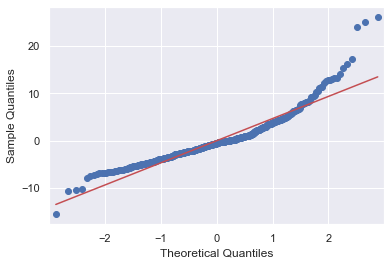

```python
# QQ plot of Residuals
res = model.resid
sm.qqplot(res, line='s')
plt.show()
```

The problem of multicollinearity can be addressed by dropping some variables.

```python
cols_to_drop = ['indus', 'age', 'tax', 'black']
data2 = data.drop(cols_to_drop, axis=1)
X2 = data2.drop('medv', axis=1)

robust_model = sm.OLS(y, sm.add_constant(X2)).fit(cov_type='HC3')
print(robust_model.summary())
```

```
                            OLS Regression Results
==============================================================================
Dep. Variable:                   medv   R-squared:                       0.727
Model:                            OLS   Adj. R-squared:                  0.722
Method:                 Least Squares   F-statistic:                     109.0
Date:                Fri, 31 Mar 2023   Prob (F-statistic):          1.46e-111
Time:                        20:37:02   Log-Likelihood:                -1511.5
No. Observations:                 506   AIC:                             3043.
Df Residuals:                     496   BIC:                             3085.
Df Model:                           9
Covariance Type:                  HC3
==============================================================================
                 coef    std err          z      P>|z|      [0.025      0.975]
------------------------------------------------------------------------------
const         39.9841      7.713      5.184      0.000      24.867      55.101
crim          -0.1185      0.027     -4.372      0.000      -0.172      -0.065
zn             0.0366      0.014      2.663      0.008       0.010       0.063
chas           3.1394      1.319      2.381      0.017       0.555       5.724
nox          -21.3757      3.588     -5.958      0.000     -28.408     -14.344
rm             3.8506      0.818      4.708      0.000       2.248       5.454
dis           -1.4508      0.231     -6.294      0.000      -1.903      -0.999
rad            0.1046      0.048      2.159      0.031       0.010       0.199
ptratio       -1.0018      0.118     -8.482      0.000      -1.233      -0.770
lstat         -0.5535      0.089     -6.197      0.000      -0.729      -0.378
==============================================================================
Omnibus:                      160.486   Durbin-Watson:                   1.085
Prob(Omnibus):                  0.000   Jarque-Bera (JB):              623.744
Skew:                           1.400   Prob(JB):                    3.59e-136
Kurtosis:                       7.663   Cond. No.                         774.
==============================================================================

Notes:
[1] Standard Errors are heteroscedasticity robust (HC3)
```

### Interpreting Regression Coefficients

From our regression coefficients, we can observe the effect each independent variable has on `medv`. For example, a unit increase in per capita crime rate by town would decrease the median value of owner-occupied homes by $118.5 on average, ceteris paribus.

### Comparing between Models

AIC and BIC scores are two criterions we use to compare 2 models. AIC and BIC combine a term reflecting how well the model fits the data with a term that penalizes the model in proportion to its number of parameters. That is, the model with lower AIC and BIC scores is considered to be better.